# CSI-MTH 190: Intro to Data Science

Lab 5: Intro to Wrangling and Cleaning

Author

Nicholas Schwab

Published

February 23, 2026

Introduction: In this lab you will practice with some data manipulation functions. They come from the `dplyr` package. The cheatsheet can be found [here](https://rstudio.github.io/cheatsheets/html/data-transformation.html).

Specifically we’ll practice with:

- filter()
- mutate()
- case_when()
- slice_*()
- group_by() and
- sumarize()

We’ll practice these functions with the dataset `babynames`, which lists a summary of every name of every child born in the US and given a social security number since 1880. I’ll start with an example then give you some practice problems at the end.

## Install a package

**If needed** It is not difficult to install packages in R. You only need to know the name of the package, and be sure its on CRAN. With the install.packages() function R will reach out to CRAN and download the package we want. Here is its [CRAN page](https://cran.r-project.org/web/packages/babynames/index.html).

Together let’s navigate to the [github](https://github.com/hadley/babynames) repository to see how to install the released version `babynames`. Then make a new chunk and paste that command:

```r
#install.packages("babynames")
```

After you install babynames once, be sure to comment that line of code, or add #| eval: False.

## Understand the data

```r
#Load the packages we need
library(tidyverse)
library(babynames)
```

You should always understand what your data look like. Do not use view(), babynames is big and you’ll slow the server down. Call up the help menu or view the data with `head()`. in a chunk below. The data, like the package is called `babynames`.

```r
?babynames
# warning sometimes data is so big it is challenging to view() it, and head() is better.
```

## mutate()

`mutate()` creates new columns. I’d like to add a column that shows the total number of babies born to a name in a given year. To do this we’ll have to manipulate n - the number of babies born with a name in a `year` and `prop` - the proportion of the total babies born that year with that name. You’ll have to do some algebra:

Start with n/total_births = prop and solve for total.

Then you’ll pipe babynames into mutate(total = …)

**Example:** Make a new column that shows the total number of babies born in a given year. Save your data frame as babynames, overwriting the original babynames.

```r
babynames = babynames|>
    mutate(total_births = n/prop)
view(babynames)
```

**Example:** After viewing the data why is total_births not exactly the same in a given year?

## case_when()

Sometimes we’d like to rename the levels of a column based on what they currently say. For example sometimes data is stored as 0 for ‘no’ and 1 for ‘yes’. If you want your data to say ‘no’ and ‘yes’ instead of 0 and 1 you can change the levels of a variable with a case_when(). `case_when()` comes from the `dplyr` package and the arguments are formulas (i.e y~x). It looks like this: `case_when(old_value~new_value)`

For example let’s change all of the years from before 1900 to “pre-1900”, all the years from before 2000 to “pre-2000” and all the years after 2000 to “post-2000”

```r
babynames =
    babynames |> mutate(
    # Note we are making a new column called year_str.
    year_str = case_when(
        year < 1900 ~ "pre-1900",
        year < 2000 ~ "pre-2000",
        year >= 2000 ~ "post-2000" ,
        # Think of the True as the else, or catch all in case we missed a year.
        TRUE ~ NA
        )
)
```

## slice_*()

The slice family will subset rows based on conditions. `slice_max()` grabs the thes with maximum value. `slice_min()` the rows with the minimum value, there are also other slice_*() functions. Let’s use `slice_max()` to find the five years when the most babies were born.

```r
babynames |>
    # note that the first n, is the column name in babynames
    # the second n is a parameter of slice_max, it is the number of rows we want.
    slice_max(order_by = n, n=5)
```

```
# A tibble: 5 × 7
   year sex   name        n   prop total_births year_str
  <dbl> <chr> <chr>   <int>  <dbl>        <dbl> <chr>
1  1947 F     Linda   99686 0.0548     1817823. pre-2000
2  1948 F     Linda   96209 0.0552     1742576. pre-2000
3  1947 M     James   94756 0.0510     1857382. pre-2000
4  1957 M     Michael 92695 0.0424     2187459. pre-2000
5  1947 M     Robert  91642 0.0493     1857382. pre-2000
```

This is not quite what we want. Its the largest number of births per name/sex by year. If we want to get the largest five years we’ll have to summarize a bit first.

## group_by and sumarize()

If we want to find the top five years, for all the babies born in that year we’ll have to first group_by() year. Summarize accordingly then slice_max().

```r
babynames |>
    group_by(year)|>
    summarise(total = sum(n)) |>
    slice_max(total, n=5)
```

```
# A tibble: 5 × 2
   year   total
  <dbl>   <int>
1  1957 4200007
2  1959 4156434
3  1960 4154377
4  1961 4140244
5  1958 4131657
```

Note that all of these years coincide with the boomer generation.

## filter()

If you wanted to see what year had the highest total births for a given name you could filter by that name first. For example I might filter for Nic or Nicholas as those are two names I go by often. Then I would repeat the analysis above to find which year had the most children named Nicholas born.

```r
babynames |>
    filter(name %in% c("Nic", "Nick", "Nicholas"))|>
    group_by(year)|>
    summarise(total = sum(n)) |>
    slice_max(total, n=10)
```

```
# A tibble: 10 × 2
    year total
   <dbl> <int>
 1  1995 29426
 2  1989 28595
 3  1993 28413
 4  1990 28199
 5  1992 28061
 6  1994 28024
 7  1996 27945
 8  1991 27630
 9  1997 27454
10  1998 26856
```

NOTE: When filtering by multiple values its important to use the %in% operator. When just one value you can use == instead. Also the c() struture in R is called a vector. It is similar to a list or an array in other languages. Data Frames are really just a bunch of vectors put together.

## Exercises Part 1

```r
# This just resets the babynames dataframe to the original, not the one we edited in the lines above.
babynames = babynames::babynames
```

In the following set of exercises I will guide you through the process of making a graph of your name for the years 1880- 2017.

**Problem 1:** The first thing you want to do is filter() the data so that is only includes your name and similar nicknames. After you filter save your data to a variable (perhaps `babyname_yourname`).

**Solution:** Make a chunk for the filtering below.

```r
babynames_nic = babynames |>
    filter(name %in% c("Nic", "Nick", "Nicholas"))
```

**Problem 2:** Now that we’ve filtered we should make a line graph of the number of babies born `n` by the `year` they were born.

**Solution:** Make a chunk and use `ggplot()` and `geom_line()` complete problem 2.

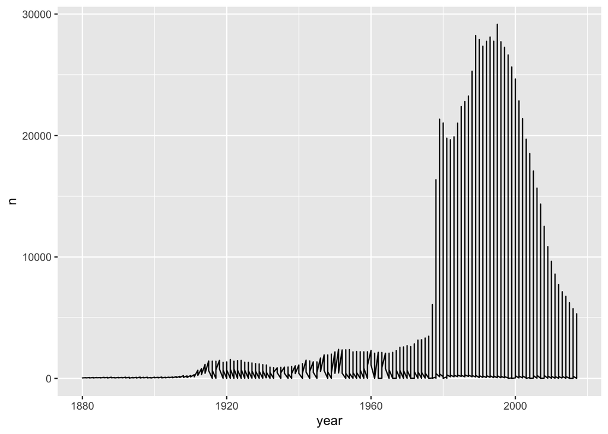

```r
babynames_nic |>
    ggplot()+
    geom_line(aes(x= year, y = n))
```

**Problem 3:** You’ll notice there is a problem, depending on your name, your graph probably oscillates to make a jagged appearance. Your task is to figure out why its happening and fix it with `group_by()` and `summarize()`, then pipe it into a new line graph without it oscillating. Then tidy up your line graph with a title, better axes labels and a better looking theme.

**Solution:**

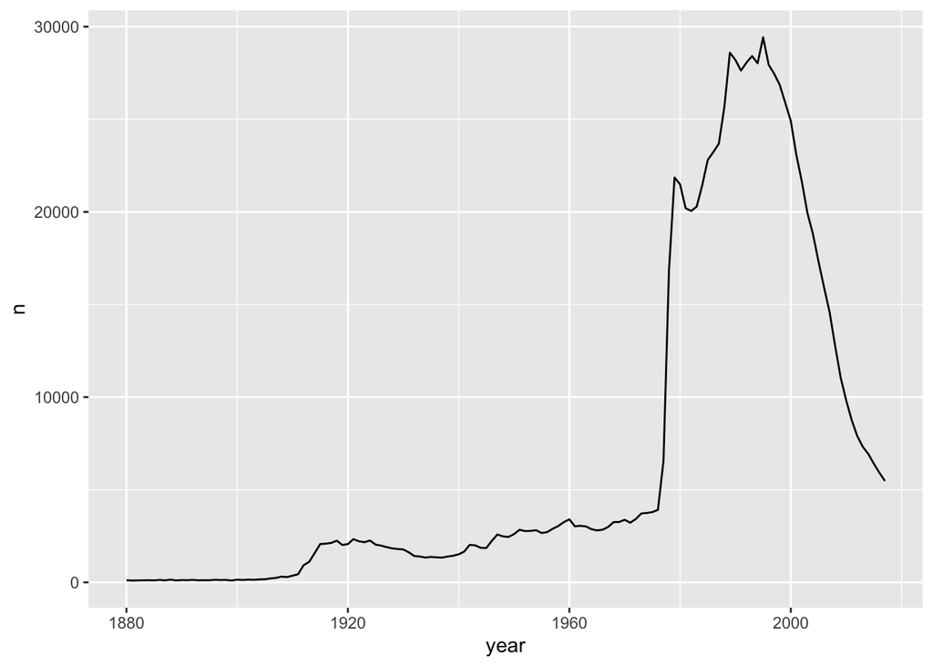

```r
babynames_nic |>
    group_by(year)|>
    summarise(n=sum(n))|>
    ggplot()+
    geom_line(aes(x= year, y = n))
```

## Excercises Part 2

What I’d like to do now is divide up the years by generations then make a bar graph of the total births by generation. The goal is to understand the total number of births in each generation.

To do this we’ll have to agree on dates for common generation names in the US. Here is one breakdown listed on [wikipedia](https://en.wikipedia.org/wiki/Generation#List_of_social_generations).

| Years | Name |
| --- | --- |
| 1883-1900 | Lost Generation |
| 1901-1927 | Greatest Generation |
| 1928-1945 | Silent Generation |
| 1946-1964 | Baby Boomers |
| 1965-1980 | Generation X |
| 1981-1996 | Millennials |
| 1997-2012 | Zoomers |
| 2013-present | Generation Alpha |

**Problem 4:** Use `case_when()` and `mutate()` to add a new column called “generation_name” that takes the year column and labels it with the correct generation. Save this dataframe as `generations`.

**Solution:**

```r
generations = babynames|>
    mutate(generation = case_when(
        year < 1883    ~ "No name",
        year < 1901    ~ "Lost Generation",
        year < 1928    ~ "Greatest Generation",
        year < 1946    ~ "Silent Generation",
        year < 1965    ~ "Baby Boomers",
        year < 1981    ~ "Generation X",
        year < 1997    ~ "Millennials",
        year < 2013    ~ "Zoomers",
        year >= 2013   ~ "Generation Alpha ",
        TRUE ~ "No name"
    ))
```

**Problem 5:** Using the `generations` dataframe, group_by() and summarize() find the total number of births by generation, then use `geom_col()` to make a nice bar graph showing the generation_name on the y-axis and the total births on the x-axis.

**Solution:**

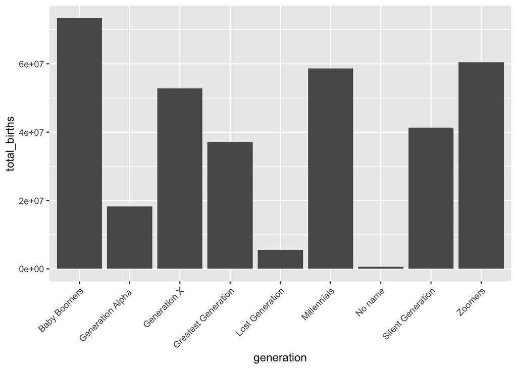

```r
generations |>
    group_by(generation) |>
    summarise(total_births = sum(n))|>
    ggplot()+
    geom_col(aes(generation,total_births))+
    theme(
    axis.text.x = element_text(angle = 45, vjust = 1, hjust = 1)
  )
```

**Problem 6:** Edit the code above to group by biological sex as well as generations. Then remake the graph to color by sex. What do you notice?

**Solution:**

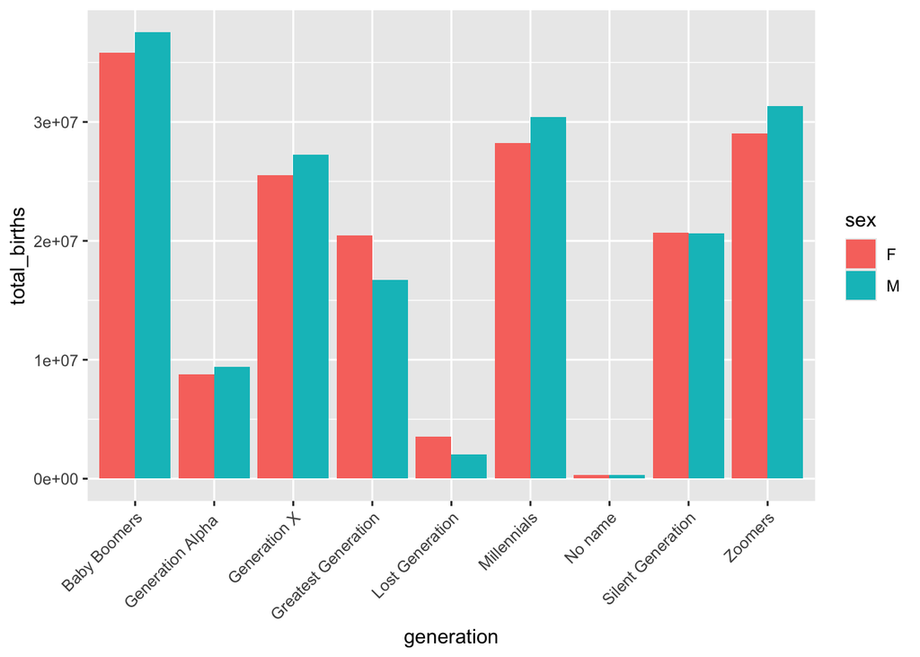

```r
generations |>
    group_by(generation,sex) |>
    summarise(total_births = sum(n))|>
    ggplot()+
    geom_col(aes(
        generation,
        total_births,
        fill = sex),
        position= "dodge")+
    theme(
    axis.text.x = element_text(angle = 45, vjust = 1, hjust = 1)
  )
```

## Exercises part #3

**Problem 7:** Subset the `generations` data to only both the Millennial and Zoomer generations and find the three most popular names from both generations. You will need the `%in%` operator and a vector `c()`. I found `ungroup()` or a second `group_by()` helpful. Your answer should have six rows.

**Solution:**

```r
generations |>
    filter(generation %in% c("Millennials","Zoomers"))|>
    group_by(name, generation)|>
    summarise(n = sum(n))|>
    ungroup()|>
    slice_max(order_by = n, n = 3, by=generation)
```

```
# A tibble: 6 × 3
  name        generation       n
  <chr>       <chr>        <int>
1 Jacob       Zoomers     441655
2 Michael     Zoomers     410192
3 Joshua      Zoomers     358072
4 Michael     Millennials 955435
5 Christopher Millennials 788462
6 Jessica     Millennials 685569
```

**Problem 8:** Use `filter()` and `str_detect()` to find the top three names from the Millennial and Zoomer generation that start with “E”. You should only have to add **max** one line to your answer to number 7. Save your answer as `gen_top6` for problem 9, make sure the six names and their totals still show in the rendered document.

**Solution:**

```r
gen_top6 = generations |>
    filter(generation %in% c("Millennials","Zoomers"))|>
    group_by(name, generation)|>
    summarise(n = sum(n))|>
    ungroup()|>
    filter(  str_detect(name, "^E"))|>
    slice_max(order_by = n, n = 3, by=generation)
```

**Problem 9:** For each generation in the `generations` dataset find the average number of the top 6 names you found in problem 8. Your answer should have 45 rows.

**Solution:**

```r
# If you save your answer to number 8 as gen_top6. This code will pull the top six names, so you don't have to retype them.

top_6_names = gen_top6 |> pull(name)

generations |>
    filter(name %in% top_6_names)|>
    group_by(name, generation)|>
    summarise(avg = mean(n))
```

```
# A tibble: 45 × 3
# Groups:   name [5]
   name      generation              avg
   <chr>     <chr>                 <dbl>
 1 Elizabeth "Baby Boomers"        8129.
 2 Elizabeth "Generation Alpha "   4723
 3 Elizabeth "Generation X"        7559.
 4 Elizabeth "Greatest Generation" 5033.
 5 Elizabeth "Lost Generation"     1590.
 6 Elizabeth "Millennials"         9607.
 7 Elizabeth "No name"             1199.
 8 Elizabeth "Silent Generation"   5131.
 9 Elizabeth "Zoomers"             6554.
10 Emily     "Baby Boomers"        1099
# ℹ 35 more rows
```